# MATH 2319 : Project Phase 1

1.Parvi Verma (s3744398) 2.Pranav Karambelkar (s3715015)

April 27, 2019

## Introduction

The dataset consists of samples corresponding to 23 species of gilled mushrooms. The gill mushrooms contain some of the most familiar types of mushrooms (https://www.sciencedaily.com/terms/agaricales.htm). Each species is identified as either definitely edible or definitely poisonous.

The guide clearly says that there is ‘no simple rule for determining the edibility’ of a mushroom and hence, the features in the dataset need to fit a machine learning model for a better investigation of which among them would be the most indicative of a poisonous mushroom.(https://www.kaggle.com/uciml/mushroom-classification/version/1)

## Objective

The objective of this project is to predict whether a mushroom with specified characteristics will be edible or poisonous. This project has two phases: Phase1 contains data preparation and data exploration which is covered in this part of report and Phase 2 will be focused on using machine learning algorithms to classify mushrooms. The ‘target’ variable is taken as target feature, which has response as either edible or poisonous. This report covers the necessary data preparation techniques required to tidy up the data and then with help of plots and charts all the variables are checked against target variable to deduce some relationship.

## Source

Source of the dataset is as follows

```
1. Parent Source: www.kaggle.com
2. Link: https://www.kaggle.com/uciml/mushroom-classification/version/1
3. The dataset was originally contributed to the UCI Machine Learning repository.
4. Time Period: Donated to UCI ML 27th April 1987
5. Link for UCI: https://archive.ics.uci.edu/ml/datasets/Mushroom
```

## Dataset

This dataset describes hypothetical samples of 23 species of mushroom collected from The Audubon Society Field Guide to North American Mushrooms (1981). Each observation is classified as definitely edible or definitely poisonous.The dataset contains 8124 observations and 23 variables. All the variables in dataset are categorical variables.

The attribute information as per the repository as follows;

```
1. class: edible=e, poisonous=p
2. cap-shape: bell=b,conical=c,convex=x,flat=f, knobbed=k,sunken=s
3. cap-surface: fibrous=f,grooves=g,scaly=y,smooth=s
4. cap-color: brown=n,buff=b,cinnamon=c,gray=g,green=r, pink=p,purple=u,red=e,white=w,yellow=y
5. bruises: bruises=t,no=f
6. odor: almond=a,anise=l,creosote=c,fishy=y,foul=f, musty=m,none=n,pungent=p,spicy=s
7. gill-attachment: attached=a,descending=d,free=f,notched=n
8. gill-spacing: close=c,crowded=w,distant=d
9. gill-size: broad=b,narrow=n
10. gill-color: black=k,brown=n,buff=b,chocolate=h,gray=g, green=r,orange=o,pink=p,purple=u,red=e, white=w,yellow=y
11. stalk-shape: enlarging=e,tapering=t
12. stalk-root: bulbous=b,club=c,cup=u,equal=e, rhizomorphs=z,rooted=r,missing=? 12. stalk-surface-above-ring: fibrous=f,scaly=y,silky=k,smooth=s
13. stalk-surface-above-ring: fibrous=f,scaly=y,silky=k,smooth=s
14. stalk-surface-below-ring: fibrous=f,scaly=y,silky=k,smooth=s
15. stalk-color-above-ring: brown=n,buff=b,cinnamon=c,gray=g,orange=o, pink=p,red=e,white=w,yellow=y
16. stalk-color-below-ring: brown=n,buff=b,cinnamon=c,gray=g,orange=o, pink=p,red=e,white=w,yellow=y
17. veil-type: partial=p,universal=u
18. veil-color: brown=n,orange=o,white=w,yellow=y
19. ring-number: none=n,one=o,two=t
20. ring-type: cobwebby=c,evanescent=e,flaring=f,large=l, none=n,pendant=p,sheathing=s,zone=z
21. spore-print-color: black=k,brown=n,buff=b,chocolate=h,green=r, orange=o,purple=u,white=w,yellow=y
22. population: abundant=a,clustered=c,numerous=n, scattered=s,several=v,solitary=y
23. habitat: grasses=g,leaves=l,meadows=m,paths=p, urban=u,waste=w,woods=d
```

(https://archive.ics.uci.edu/ml/datasets/Mushroom)

## Target Feature

The target feature classifies each observation as whether it is definitely edible or definitely poisonous. The response feature is ‘class’ which has been renamed as ‘target’ in the data pre-processing phase for ease of understanding. It is given as;

```
1. Edible
2. Poisonous
```

The analysis is a binary classification probelm since, the target feature has two classes.

## I.Data Preprocessing

The main objective of this step is to prepare the data for further analysis. The quality of data that we get out of this step will define the accuracy of our further analysis. Raw data can have many anomalies like missing values,impossible values etc. This process rectifies all these anomalies and provides us with a good quality data to perform our further analysis on.

## 1.Importing the data and loading necessary packages

```r
library(readr)
library(outliers)
library(readxl)
library(magrittr)
library(lubridate)
library(tidyr)
library(dplyr)
```

```r
library(forecast)
library(ggplot2)
library(ggthemes)
library(gridExtra)
mushrooms <- read_csv("mushrooms.csv")
```

## 2. Understanding the data and data structures

```r
str(mushrooms)
```

```
## Classes 'tbl_df', 'tbl' and 'data.frame':    8124 obs. of  23 variables:
##  $ class                   : chr  "p" "e" "e" "p" ...
##  $ cap-shape               : chr  "x" "x" "b" "x" ...
##  $ cap-surface             : chr  "s" "s" "s" "y" ...
##  $ cap-color               : chr  "n" "y" "w" "w" ...
##  $ bruises                 : chr  "t" "t" "t" "t" ...
##  $ odor                    : chr  "p" "a" "l" "p" ...
##  $ gill-attachment         : chr  "f" "f" "f" "f" ...
##  $ gill-spacing            : chr  "c" "c" "c" "c" ...
##  $ gill-size               : chr  "n" "b" "b" "n" ...
##  $ gill-color              : chr  "k" "k" "n" "n" ...
##  $ stalk-shape             : chr  "e" "e" "e" "e" ...
##  $ stalk-root              : chr  "e" "c" "c" "e" ...
##  $ stalk-surface-above-ring: chr  "s" "s" "s" "s" ...
##  $ stalk-surface-below-ring: chr  "s" "s" "s" "s" ...
##  $ stalk-color-above-ring  : chr  "w" "w" "w" "w" ...
##  $ stalk-color-below-ring  : chr  "w" "w" "w" "w" ...
##  $ veil-type               : chr  "p" "p" "p" "p" ...
##  $ veil-color              : chr  "w" "w" "w" "w" ...
##  $ ring-number             : chr  "o" "o" "o" "o" ...
##  $ ring-type               : chr  "p" "p" "p" "p" ...
##  $ spore-print-color       : chr  "k" "n" "n" "k" ...
##  $ population              : chr  "s" "n" "n" "s" ...
##  $ habitat                 : chr  "u" "g" "m" "u" ...
##  - attr(*, "spec")=List of 2
##   ..$ cols   :List of 23
##   .. ..$ class                   : list()
##   .. .. ..- attr(*, "class")= chr  "collector_character" "collector"
##   .. ..$ cap-shape               : list()
##   .. .. ..- attr(*, "class")= chr  "collector_character" "collector"
##   .. ..$ cap-surface             : list()
##   .. .. ..- attr(*, "class")= chr  "collector_character" "collector"
##   .. ..$ cap-color               : list()
##   .. .. ..- attr(*, "class")= chr  "collector_character" "collector"
##   .. ..$ bruises                 : list()
##   .. .. ..- attr(*, "class")= chr  "collector_character" "collector"
##   .. ..$ odor                    : list()
##   .. .. ..- attr(*, "class")= chr  "collector_character" "collector"
##   .. ..$ gill-attachment         : list()
##   .. .. ..- attr(*, "class")= chr  "collector_character" "collector"
```

[output cut: 20 more lines]

```
##   .. ..$ veil-color              : list()
##   .. .. ..- attr(*, "class")= chr  "collector_character" "collector"
##   .. ..$ ring-number             : list()
##   .. .. ..- attr(*, "class")= chr  "collector_character" "collector"
##   .. ..$ ring-type               : list()
##   .. .. ..- attr(*, "class")= chr  "collector_character" "collector"
##   .. ..$ spore-print-color       : list()
##   .. .. ..- attr(*, "class")= chr  "collector_character" "collector"
##   .. ..$ population              : list()
##   .. .. ..- attr(*, "class")= chr  "collector_character" "collector"
##   .. ..$ habitat                 : list()
##   .. .. ..- attr(*, "class")= chr  "collector_character" "collector"
##   ..$ default: list()
##   .. ..- attr(*, "class")= chr  "collector_guess" "collector"
##   ..- attr(*, "class")= chr "col_spec"
```

The data has 8124 observations of 23 variables. All variables are character variables which in turn are categorical variables.

```r
colnames(mushrooms)
```

```
##  [1] "class"                    "cap-shape"
##  [3] "cap-surface"              "cap-color"
##  [5] "bruises"                  "odor"
##  [7] "gill-attachment"          "gill-spacing"
##  [9] "gill-size"                "gill-color"
## [11] "stalk-shape"              "stalk-root"
## [13] "stalk-surface-above-ring" "stalk-surface-below-ring"
## [15] "stalk-color-above-ring"   "stalk-color-below-ring"
## [17] "veil-type"                "veil-color"
## [19] "ring-number"              "ring-type"
## [21] "spore-print-color"        "population"
## [23] "habitat"
```

The variable names are self explainatory and they can specify their class in distinctive way. The variable ‘class’ is to rename as ‘target’ for ease of understanding.

```r
head(mushrooms)
```

```
## # A tibble: 6 x 23
##   class `cap-shape` `cap-surface` `cap-color` bruises odor
##   <chr> <chr>       <chr>         <chr>       <chr>   <chr>
## 1 p     x           s             n           t       p
## 2 e     x           s             y           t       a
## 3 e     b           s             w           t       l
## 4 p     x           y             w           t       p
## 5 e     x           s             g           f       n
## 6 e     x           y             y           t       a
## # ... with 17 more variables: `gill-attachment` <chr>,
## #   `gill-spacing` <chr>, `gill-size` <chr>, `gill-color` <chr>,
## #   `stalk-shape` <chr>, `stalk-root` <chr>,
## #   `stalk-surface-above-ring` <chr>, `stalk-surface-below-ring` <chr>,
## #   `stalk-color-above-ring` <chr>, `stalk-color-below-ring` <chr>,
## #   `veil-type` <chr>, `veil-color` <chr>, `ring-number` <chr>,
## #   `ring-type` <chr>, `spore-print-color` <chr>, population <chr>,
## #   habitat <chr>
```

It can be visualised that the levels of all variables are expressed only in a single letter (mostly the initial letter) and its leading to ambuiguity in the data. If we take such a data for furhter analysis we might need to refer to the attribute information on every instance. Hence, renaming the attribute levels would ease the understanding of the data set.

## 3. Tidy and Manipulate

Following are the steps involved;

# a. Renaming the target feature and rearranging it to the end of the data set

```r
colnames(mushrooms)[colnames(mushrooms)=="class"] <- "target"
data1 <- mushrooms[,c(2,3,4,5,6,7,8,9,10,11,12,13,14,15,16,17,18,19,20,21,22,23,1)]
colnames(data1)
```

```
##  [1] "cap-shape"                "cap-surface"
##  [3] "cap-color"                "bruises"
##  [5] "odor"                     "gill-attachment"
##  [7] "gill-spacing"             "gill-size"
##  [9] "gill-color"               "stalk-shape"
## [11] "stalk-root"               "stalk-surface-above-ring"
## [13] "stalk-surface-below-ring" "stalk-color-above-ring"
## [15] "stalk-color-below-ring"   "veil-type"
## [17] "veil-color"               "ring-number"
## [19] "ring-type"                "spore-print-color"
## [21] "population"               "habitat"
## [23] "target"
```

# b. Renaming the levels of each attibute for ease of understanding

```r
#1) cap-shape
data1$`cap-shape`<- factor(data1$`cap-shape`,levels = c("b","c","x","f","k","s"),labels = c("bell","conical","convex","flat","knobbed","sunken"))

#2)cap-surface
data1$`cap-surface`<- factor(data1$`cap-surface`,levels = c("f","g","y","s"),labels = c("fibrous","grooves","scaly","smooth"))

#3)cap-color: brown=n,buff=b,cinnamon=c,gray=g,green=r,pink=p,purple=u,red=e,white=w,yellow=y
data1$`cap-color`<- factor(data1$`cap-color`,levels = c("n","b","c","g","r","p", "u", "e", "w", "y"),labels = c("brown","buff","cinnamon","grey","green","pink", "purple", "red", "white", "yellow"))

#4)bruises: bruises=t,no=f
data1$bruises <- factor(data1$bruises, levels = c("t", "f"), labels = c("yes", "no"))

#5)odor: almond=a,anise=l,creosote=c,fishy=y,foul=f,musty=m,none=n,pungent=p,spicy=s
data1$odor <- factor(data1$odor, levels = c("a", "l", "c", "y", "f", "m", "n", "p", "s"), labels = c("almond", "anise", "creosote", "fishy", "foul", "musty", "none", "pungent", "spicy" ))

#6)gill-attachment: attached=a,descending=d,free=f,notched=n
data1$`gill-attachment`<- factor(data1$`gill-attachment`,levels = c("a","d","f","n"),labels = c("attached","descending","free","notched"))

#7)gill-spacing: close=c,crowded=w,distant=d
data1$`gill-spacing`<- factor(data1$`gill-spacing`,levels = c("c","w","d"),labels = c("close","crowded","distant"))

#8)gill-size: broad=b,narrow=n
data1$`gill-size`<- factor(data1$`gill-size`,levels = c("b","n"),labels = c("broad","narrow"))

#9)gill-color: black=k,brown=n,buff=b,chocolate=h,gray=g, green=r,orange=o,pink=p,purple=u,red=e,white=w,yellow=y
data1$`gill-color`<- factor(data1$`gill-color`,levels = c("k","n","b","h","g","r","o","p", "u", "e", "w", "y"),labels = c("black","brown","buff","chocolate","grey","green","orange","pink", "purple", "red", "white", "yellow"))

#10)stalk-shape: enlarging=e,tapering=t
data1$`stalk-shape`<- factor(data1$`stalk-shape`,levels = c("e","t"),labels = c("enlarging","tapering"))

#11)stalk-root: bulbous=b,club=c,cup=u,equal=e,rhizomorphs=z,rooted=r,unknown=?
data1$`stalk-root` <- factor(data1$`stalk-root`, levels = c("b", "c", "u", "e", "z", "r", "?"), labels = c("bulbous", "club", "cup", "equal", "rhizomorphs", "rooted", "unknown"))

#12)stalk-surface-above-ring: fibrous=f,scaly=y,silky=k,smooth=s
data1$`stalk-surface-above-ring` <- factor(data1$`stalk-surface-above-ring`, levels = c("f", "y", "k", "s"), labels = c("fibrous", "scaly", "silky", "smooth"))

#13)stalk-surface-below-ring: fibrous=f,scaly=y,silky=k,smooth=s
data1$`stalk-surface-below-ring` <- factor(data1$`stalk-surface-below-ring`, levels = c("f", "y", "k", "s"), labels = c("fibrous", "scaly", "silky", "smooth"))

#14)stalk-color-above-ring: brown=n,buff=b,cinnamon=c,gray=g,orange=o,pink=p,red=e,white=w,yellow=y
data1$`stalk-color-above-ring` <- factor(data1$`stalk-color-above-ring`, levels = c("n", "b", "c", "g", "o", "p", "e", "w", "y"), labels = c("brown", "buff", "cinnamon", "grey", "orange", "pink", "red", "white", "yellow"))

#15)stalk-color-below-ring: brown=n,buff=b,cinnamon=c,gray=g,orange=o,pink=p,red=e,white=w,yellow=y
data1$`stalk-color-below-ring` <- factor(data1$`stalk-color-below-ring`, levels = c("n", "b", "c", "g", "o", "p", "e", "w", "y"), labels = c("brown", "buff", "cinnamon", "grey", "orange", "pink", "red", "white", "yellow"))

#16)veil-type: partial=p,universal=u
data1$`veil-type` <- factor(data1$`veil-type`, levels = c("p", "u"), labels = c("partial", "universal"))

#17)veil-color: brown=n,orange=o,white=w,yellow=y
data1$`veil-color` <- factor(data1$`veil-color`, levels = c("n", "o", "w", "y"), labels = c("brown", "orange", "white", "yellow"))

#18)ring-number: none=n,one=o,two=t
data1$`ring-number` <- factor(data1$`ring-number`, levels = c("n", "o", "t"), labels = c("none", "one", "two"))

#19)ring-type: cobwebby=c,evanescent=e,flaring=f,large=l,none=n,pendant=p,sheathing=s,zone=z
data1$`ring-type` <- factor(data1$`ring-type`, levels= c("c", "e", "f", "l", "n", "p", "s", "z"), labels = c("cowebby", "evanescent", "flaring", "large", "none", "pendant", "sheathing", "zone"))

#20)spore-print-color: black=k,brown=n,buff=b,chocolate=h,green=r,orange=o,purple=u,white=w,yellow=y
data1$`spore-print-color` <- factor(data1$`spore-print-color`, levels = c("k", "n", "b", "h", "r", "o", "u", "w", "y"),labels = c("black","brown","buff","chocolate","green","orange", "purple", "white", "yellow"))

#21)population: abundant=a,clustered=c,numerous=n,scattered=s,several=v,solitary=y
data1$population <- factor(data1$population, levels = c("a", "c", "n", "s", "v", "y"), labels = c("abundant", "clustered", "numerous", "scattered", "several", "solitary"))

#22)habitat: grasses=g,leaves=l,meadows=m,paths=p,urban=u,waste=w,woods=d
data1$habitat <- factor(data1$habitat, levels = c("g", "l", "m", "p", "u", "w", "d"), labels = c("grasses", "leaves", "meadows", "paths", "urban", "waste", "woods"))

#23)target:(edible=e, poisonous=p)
data1$target <- factor(data1$target, levels = c("e", "p"), labels = c("edible", "poisonous"))

head(data1)
```

```
## # A tibble: 6 x 23
##   `cap-shape` `cap-surface` `cap-color` bruises odor  `gill-attachmen~
##   <fct>       <fct>         <fct>       <fct>   <fct> <fct>
## 1 convex      smooth        brown       yes     pung~ free
## 2 convex      smooth        yellow      yes     almo~ free
## 3 bell        smooth        white       yes     anise free
## 4 convex      scaly         white       yes     pung~ free
## 5 convex      smooth        grey        no      none  free
## 6 convex      scaly         yellow      yes     almo~ free
## # ... with 17 more variables: `gill-spacing` <fct>, `gill-size` <fct>,
## #   `gill-color` <fct>, `stalk-shape` <fct>, `stalk-root` <fct>,
## #   `stalk-surface-above-ring` <fct>, `stalk-surface-below-ring` <fct>,
## #   `stalk-color-above-ring` <fct>, `stalk-color-below-ring` <fct>,
## #   `veil-type` <fct>, `veil-color` <fct>, `ring-number` <fct>,
## #   `ring-type` <fct>, `spore-print-color` <fct>, population <fct>,
## #   habitat <fct>, target <fct>
```

# c. Checking variables with insignificant levels and eliminating them

After checking levels of each variables, we found that, the variable ‘veil-type’ has only one level and thus, it is an insignificant variable. It will not affect the decision making of the target feature. Hence, the variable ‘veil type’ can be eliminated. Codes only related to the correpsonding variables are shown

```r
#1. Checking levels
as.data.frame(table(data1$`veil-type`))
```

```
##        Var1 Freq
## 1   partial 8124
## 2 universal    0
```

```r
#2. Dropping corresponding column
data2<- data1 %>% select(-16)
```

# d. Finding out missing values

```r
colSums(is.na(data2))
```

```
##                cap-shape              cap-surface                cap-color
##                        0                        0                        0
##                  bruises                     odor          gill-attachment
##                        0                        0                        0
##             gill-spacing                gill-size               gill-color
##                        0                        0                        0
##              stalk-shape               stalk-root stalk-surface-above-ring
##                        0                        0                        0
## stalk-surface-below-ring   stalk-color-above-ring   stalk-color-below-ring
##                        0                        0                        0
##               veil-color              ring-number                ring-type
##                        0                        0                        0
##        spore-print-color               population                  habitat
##                        0                        0                        0
##                   target
##                        0
```

There are no any missing values in the data.

## II.Data Exploration

The main objective of this step is to get a deep insight about the data. This step helps to get a clear vision of data and understand the main characteristics of the data. The techniques used in this investigation are Graphical techniques. Graphical techniques include scatter plot, histogram, pie-chart, line graph, bar graph etc.

# 1.Univariate Visualisation

# a.Target

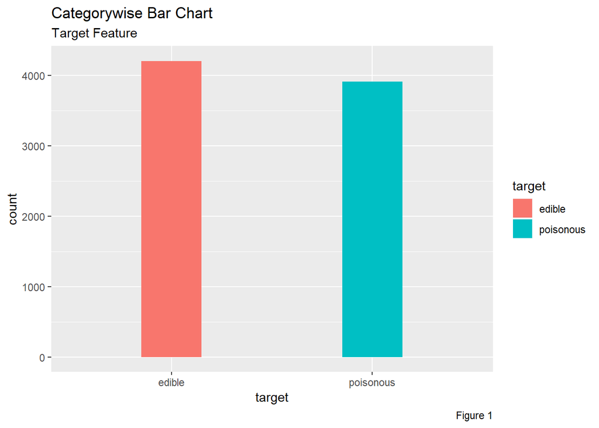

```r
t <- ggplot(data2, aes(target)) +
  geom_bar(aes(fill= target), width= 0.3) +
  labs(title="Categorywise Bar Chart",
       subtitle="Target Feature",
       caption="Figure 1")
plot(t)
```

We have roughly 4K observations for both the categories.

# b.Cap shape, Cap Surface, Cap color, bruises

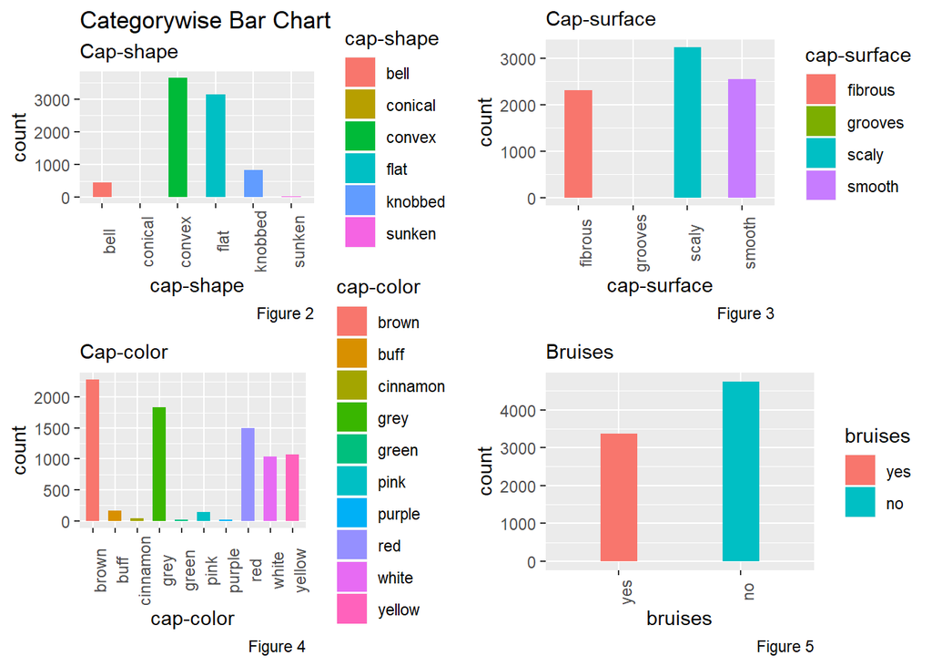

```r
cs <- ggplot(data2, aes(`cap-shape`)) +
  geom_bar(aes(fill= `cap-shape`), width= 0.5) +
  labs(title="Categorywise Bar Chart",
       subtitle="Cap-shape",
       caption="Figure 2") +
  theme(axis.text.x = element_text(angle = 90))
cse <- ggplot(data2, aes(`cap-surface`)) +
  geom_bar(aes(fill= `cap-surface`), width= 0.5) +
  labs( subtitle="Cap-surface",
       caption="Figure 3") +
  theme(axis.text.x = element_text(angle = 90))
cc <- ggplot(data2, aes(`cap-color`)) +
  geom_bar(aes(fill= `cap-color`), width= 0.6) +
  labs(subtitle="Cap-color",
       caption="Figure 4") +
  theme(axis.text.x = element_text(angle = 90))
b <- ggplot(data2, aes(bruises)) +
  geom_bar(aes(fill= bruises), width= 0.3) +
  labs(subtitle="Bruises",
       caption="Figure 5") +
  theme(axis.text.x = element_text(angle = 90))
grid.arrange(cs, cse, cc, b, ncol=2)
```

From fig 2, Majority of the observations falls under convex and flat shape, whereas observations under other shapes are significantly low.

From fig 3, We could visualise a fair distribution among three categories and no count for grooves typed surface.

From fig 4, We could visualise a fair distribution among brown, grey, red, white and yellow whereas there are few observations among other types.

From fig 5, We could visualise that more mushrooms were found to have no bruises as compared to the ones with bruises.

# c.Odor, Gill-attachment, Gill-spacing, Gill-size

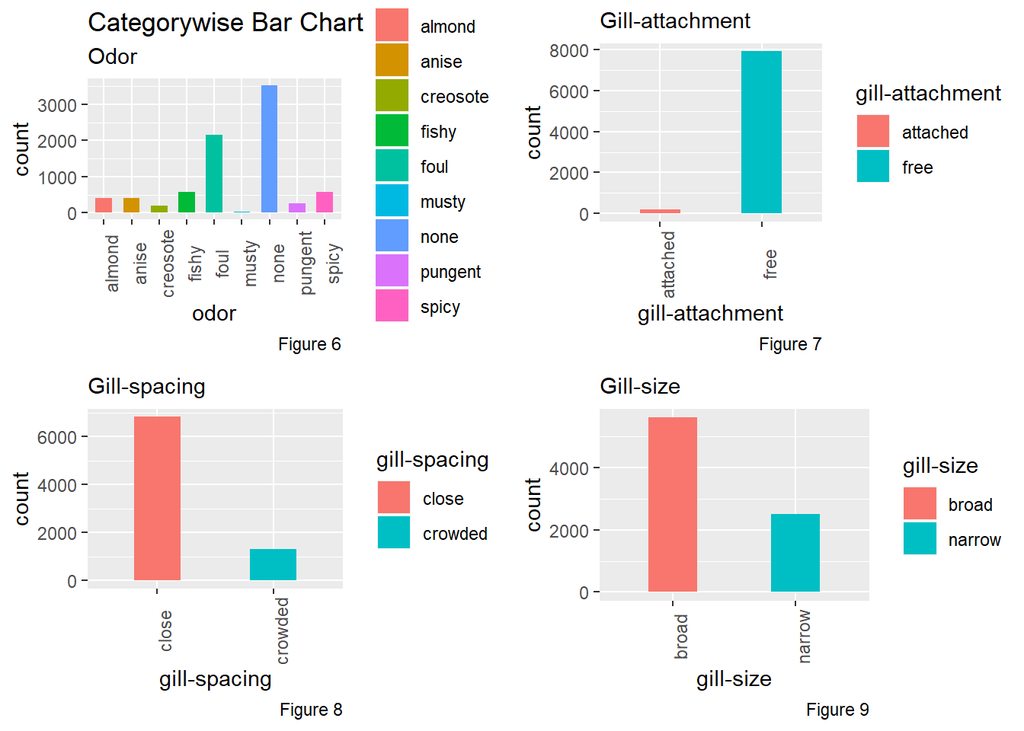

```r
o <- ggplot(data2, aes(odor)) +
  geom_bar(aes(fill= odor), width= 0.6) +
  labs(title="Categorywise Bar Chart",
       subtitle="Odor",
       caption="Figure 6") + theme(axis.text.x = element_text(angle = 90))
ga <- ggplot(data2, aes(`gill-attachment`)) +
  geom_bar(aes(fill= `gill-attachment`), width= 0.4) +
  labs(subtitle="Gill-attachment",
       caption="Figure 7") + theme(axis.text.x = element_text(angle = 90))
gs <- ggplot(data2, aes(`gill-spacing`)) +
  geom_bar(aes(fill= `gill-spacing`), width= 0.4) +
  labs(subtitle="Gill-spacing",
       caption="Figure 8") + theme(axis.text.x = element_text(angle = 90))
gsz <- ggplot(data2, aes(`gill-size`)) +
  geom_bar(aes(fill= `gill-size`), width= 0.4) +
  labs(subtitle="Gill-size",
       caption="Figure 9") + theme(axis.text.x = element_text(angle = 90))
grid.arrange(o, ga, gs, gsz, ncol=2)
```

From Fig 6, We could visualise a majority of mushrooms fall under none and foul odor whereas whereas observations under other odor are low.

From Fig 7, We could visualise that majority of mushroom samples were falling under free category of gill-attachment.

From Fig 8, We could visualise that majority of mushroom samples were falling under close category of gill-spacing.

From Fig 9, We could visualise that majority of mushroom samples were falling under broad category of gill-size.

# d.Gill-color, stalk-shape, stalk-root

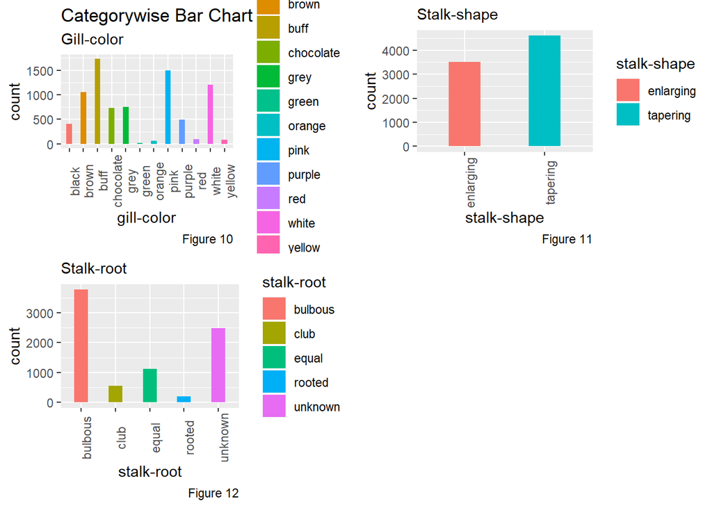

```r
gcl <- ggplot(data2, aes(`gill-color`)) +
  geom_bar(aes(fill= `gill-color`), width= 0.4) +
  labs(title="Categorywise Bar Chart",
       subtitle="Gill-color",
       caption="Figure 10") + theme(axis.text.x = element_text(angle = 90))
ss <- ggplot(data2, aes(`stalk-shape`)) +
  geom_bar(aes(fill= `stalk-shape`), width= 0.4) +
  labs(subtitle="Stalk-shape",
       caption="Figure 11") + theme(axis.text.x = element_text(angle = 90))
sr <- ggplot(data2, aes(`stalk-root`)) +
  geom_bar(aes(fill= `stalk-root`), width= 0.4) +
  labs(subtitle="Stalk-root",
       caption="Figure 12") + theme(axis.text.x = element_text(angle = 90))
grid.arrange(gcl,ss,sr, ncol=2)
```

From Fig 10, We could visualise a majority of mushrooms fall under buff, pink and white followed by brown, chocolate, grey, black and purple whereas there are few observations among other types.

From Fig 11, We could visualise that more mushrooms fall under tapering category as compared to enlarging category of stalk-shape.

From Fig 12, We could visualise a majority of mushrooms fall under bulbous category followed by unknown category whereas observations under other categories are low.

# e.Stalk-surface-above-ring, stalk-surface-below-ring, Stalk-color above the ring, Stalk-color below the ring

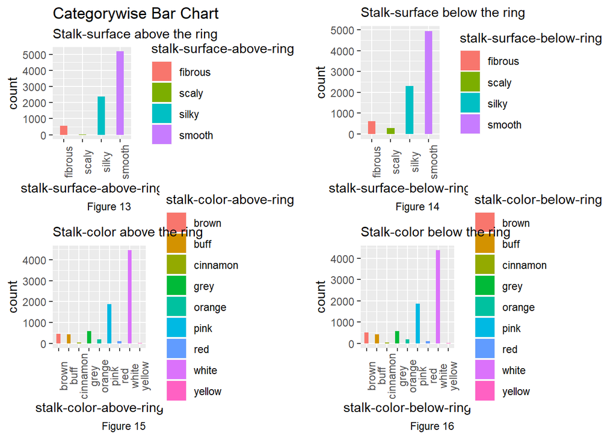

```r
ssar <- ggplot(data2, aes(`stalk-surface-above-ring`)) +
  geom_bar(aes(fill= `stalk-surface-above-ring`), width= 0.4) +
  labs(title="Categorywise Bar Chart",
       subtitle="Stalk-surface above the ring",
       caption="Figure 13") + theme(axis.text.x = element_text(angle = 90))
ssbr <- ggplot(data2, aes(`stalk-surface-below-ring`)) +
  geom_bar(aes(fill= `stalk-surface-below-ring`), width= 0.4) +
  labs(subtitle="Stalk-surface below the ring",
       caption="Figure 14") + theme(axis.text.x = element_text(angle = 90))
scar <- ggplot(data2, aes(`stalk-color-above-ring`)) +
  geom_bar(aes(fill= `stalk-color-above-ring`), width= 0.4) +
  labs(subtitle="Stalk-color above the ring",
       caption="Figure 15") + theme(axis.text.x = element_text(angle = 90))
scbr <- ggplot(data2, aes(`stalk-color-below-ring`)) +
  geom_bar(aes(fill= `stalk-color-below-ring`), width= 0.4) +
  labs(subtitle="Stalk-color below the ring",
       caption="Figure 16") + theme(axis.text.x = element_text(angle = 90))
grid.arrange(ssar,ssbr,scar,scbr, ncol=2)
```

From Fig 13, We could visualise a majority of mushrooms fall under smooth category followed by silky category whereas observations under other categories are low

From Fi 14, We could visualise a majority of mushrooms fall under smooth category followed by silky category whereas observations under other categories are low.

From Fig 15, We could visualise a majority of mushrooms fall under white followed by pink whereas observations under other categories are low.

From Fig 16, We could visualise a majority of mushrooms fall under white followed by pink category whereas observations under other categories are low.

Fig 13 & Fig 14 have a similar distribution which increases the redundancy in the dataset as both columns will deduce the same decision for target variable because of similar distribution of values under the same categories. Hence by removing one of the columns among two pairs, we reduce the redundancy in the dataset.

Similarly From Fig 15 and Fig 16, one column can be eliminated to reduce the redundancy.

```r
data3<- data2 %>% select(-13,-15)
head(data3)
```

```
## # A tibble: 6 x 20
##   `cap-shape` `cap-surface` `cap-color` bruises odor  `gill-attachmen~
##   <fct>       <fct>         <fct>       <fct>   <fct> <fct>
## 1 convex      smooth        brown       yes     pung~ free
## 2 convex      smooth        yellow      yes     almo~ free
## 3 bell        smooth        white       yes     anise free
## 4 convex      scaly         white       yes     pung~ free
## 5 convex      smooth        grey        no      none  free
## 6 convex      scaly         yellow      yes     almo~ free
## # ... with 14 more variables: `gill-spacing` <fct>, `gill-size` <fct>,
## #   `gill-color` <fct>, `stalk-shape` <fct>, `stalk-root` <fct>,
## #   `stalk-surface-above-ring` <fct>, `stalk-color-above-ring` <fct>,
## #   `veil-color` <fct>, `ring-number` <fct>, `ring-type` <fct>,
## #   `spore-print-color` <fct>, population <fct>, habitat <fct>,
## #   target <fct>
```

# f.Veil-color, ring-number, ring-type, spore-print-color

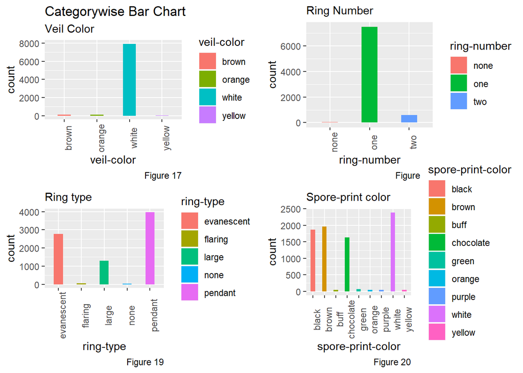

```r
vc <- ggplot(data3, aes(`veil-color`)) +
  geom_bar(aes(fill= `veil-color`), width= 0.4) +
  labs(title="Categorywise Bar Chart",
       subtitle="Veil Color",
       caption="Figure 17") + theme(axis.text.x = element_text(angle = 90))
rn <- ggplot(data3, aes(`ring-number`)) +
  geom_bar(aes(fill= `ring-number`), width= 0.4) +
  labs(subtitle="Ring Number",
       caption="Figure 18") + theme(axis.text.x = element_text(angle = 90))
rt <- ggplot(data3, aes(`ring-type`)) +
  geom_bar(aes(fill= `ring-type`), width= 0.4) +
  labs(subtitle="Ring type",
       caption="Figure 19") + theme(axis.text.x = element_text(angle = 90))
spc <- ggplot(data3, aes(`spore-print-color`)) +
  geom_bar(aes(fill= `spore-print-color`), width= 0.4) +
  labs(subtitle="Spore-print color",
       caption="Figure 20") + theme(axis.text.x = element_text(angle = 90))
grid.arrange(vc,rn,rt,spc,ncol=2)
```

From Fig 17, Majority of the mushrooms have veil color as white. We might as well group the other colors as ‘others’ except ‘white’.

From Fig 18, Majority of the mushrooms have only one ring.

From Fig 19, We could visualise a majority of mushrooms fall under pendant category followed by evanescent and large categories whereas observations under other categories are significantly low.

From Fig 20, We could visualise a majority of mushrooms fall under white category followed by brown, black and chocolate category whereas observations under other categories are significantly low.

# g.Population and habitat

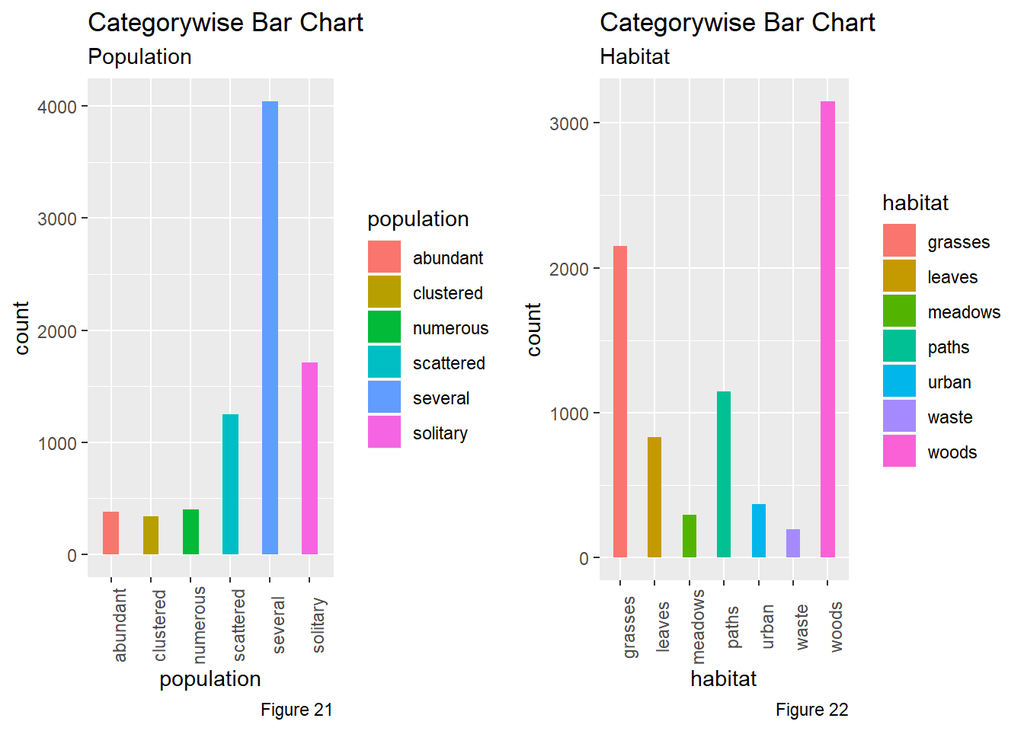

```r
p <- ggplot(data3, aes(population)) +
  geom_bar(aes(fill= population), width= 0.4) +
  labs(title="Categorywise Bar Chart",
       subtitle="Population",
       caption="Figure 21") + theme(axis.text.x = element_text(angle = 90))
h <- ggplot(data2, aes(habitat)) +
  geom_bar(aes(fill= habitat), width= 0.4) +
  labs(title="Categorywise Bar Chart",
       subtitle="Habitat",
       caption="Figure 22") + theme(axis.text.x = element_text(angle = 90))
grid.arrange(p,h,ncol=2)
```

From Fig 21, We could visualise a majority of mushrooms fall under several category followed by solitary and scattered category whereas observations under other categories are low.

From Fig 22, We could visualise a majority of mushrooms fall under woods category followed by grasses category whereas observations under other categories are low.

## 2.Multivariate Analysis

# a.Cap-shape, cap-surface, cap-color, bruises

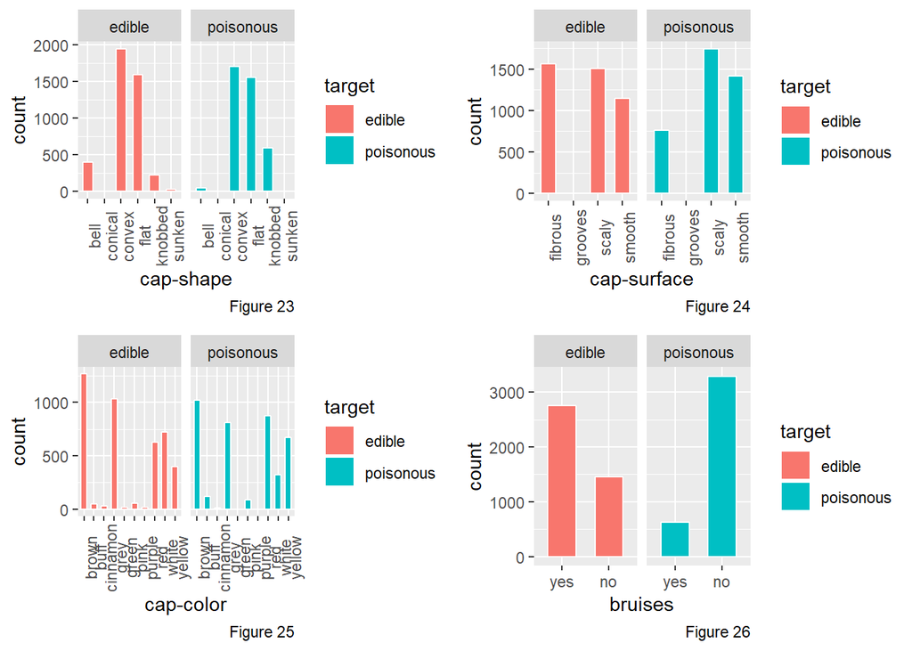

```r
cs.t <- ggplot(data3, aes(x=`cap-shape`)) +
  geom_bar(aes(fill= target), color="white", position = position_dodge(0.9), width = 0.6) + labs(caption="Figure 23") +
  facet_wrap(~target) +
  theme(axis.text.x = element_text(angle = 90))
cse.t <- ggplot(data3, aes(x=`cap-surface`)) +
  geom_bar(aes(fill= target), color="white", position = position_dodge(0.9), width = 0.6) +labs(caption="Figure 24") +
  facet_wrap(~target) + theme(axis.text.x = element_text(angle = 90))
cc.t <- ggplot(data3, aes(x=`cap-color`)) +
  geom_bar(aes(fill= target), color="white", position = position_dodge(0.9), width = 0.6) +labs(caption="Figure 25") +
  facet_wrap(~target) +
  theme(axis.text.x = element_text(angle = 90))
b.t <- ggplot(data3, aes(x=bruises)) +
  geom_bar(aes(fill= target), color="white", position = position_dodge(0.9), width = 0.6) +labs(caption="Figure 26") +
  facet_wrap(~target)
grid.arrange((cs.t), (cse.t), (cc.t), (b.t), ncol=2)
```

From Fig 23, The plot suggests that bell shape is more likely to be edible mushroom whereas knobbed shape is more likely to be poisonous mushroom.The sunken shaped mushrooms are always edible.

From Fig 24, )The plot suggests that fibrous surface is noticed more often for edible mushroom whereas scaly and smooth surface are almost equally noticed for both poisonous and edible mushrooms.

From Fig 25, The plot suggests that brown, grey and white colours are more likely to be edible mushrooms whereas red and yellow colours are more likely to be poisonous mushrooms.

From Fig 26, The plot suggests that bruises are noticed more often for edible mushrooms than poisonous whereas unaffected mushrooms are noticed to be poisonous mushrooms than edible.

# b.Odor, gill-attachment, gill-spacing, gill-size

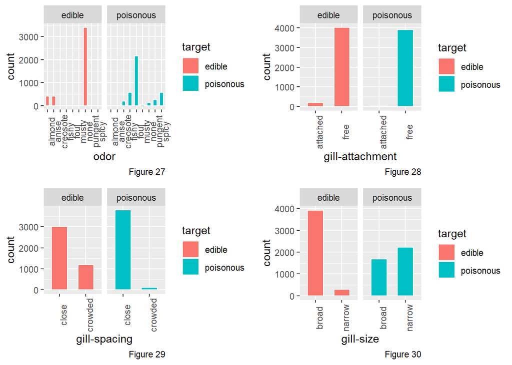

```r
o.t <- ggplot(data3, aes(x=odor)) +
  geom_bar(aes(fill= target), color="white", position = position_dodge(0.9), width = 0.6) + labs(caption="Figure 27") +
  facet_wrap(~target) +
  theme(axis.text.x = element_text(angle = 90))
ga.t <- ggplot(data3, aes(x=`gill-attachment`)) +
  geom_bar(aes(fill= target), color="white", position = position_dodge(0.9), width = 0.6) + labs(caption="Figure 28") +
  facet_wrap(~target) + theme(axis.text.x = element_text(angle = 90))
gs.t <- ggplot(data3, aes(x=`gill-spacing`)) +
  geom_bar(aes(fill= target), color="white", position = position_dodge(0.9), width = 0.6) + labs(caption="Figure 29") +
  facet_wrap(~target) + theme(axis.text.x = element_text(angle = 90))
gse.t <- ggplot(data3, aes(x=`gill-size`)) +
  geom_bar(aes(fill= target), color="white", position = position_dodge(0.9), width = 0.6) + labs(caption="Figure 30") +
  facet_wrap(~target) + theme(axis.text.x = element_text(angle = 90))
grid.arrange((o.t),(ga.t),(gs.t),(gse.t),ncol=2 )
```

From Fig 27, We could visualise that the odor type almond and anise are always edible while fishy and foul are always poisonous.We could visualise that the odor type almond and anise are always edible while fishy and foul are always poisonous. Mostly, no odor is found in edible mushrooms than poisonous.

From Fig 28, The plot suggests that free gill-attachment are equally noticed for poisonous and edible mushrooms whereas attached is more likely to br edible.

From Fig 29, The crowded spacing type is less likely to be poisonous.

From Fig 30, The broad gill-size is more likely to be edible whereas narrow is more likely to be poisonous.

# c.Gill-color, stalk-shape, stalk-root

```r
gc.t <- ggplot(data3, aes(x=`gill-color`)) +
  geom_bar(aes(fill= target), color="white", position = position_dodge(0.9), width = 0.6) + labs(caption="Figure 31") +
  facet_wrap(~target) +
  theme(axis.text.x = element_text(angle = 90))
ss.t <- ggplot(data3, aes(x=`stalk-shape`)) + labs(caption="Figure 32") +
  geom_bar(aes(fill= target), color="white", position = position_dodge(0.9), width = 0.6) + theme(axis.text.x = element_text(angle = 90))
  facet_wrap(~target)
```

[output not shown]

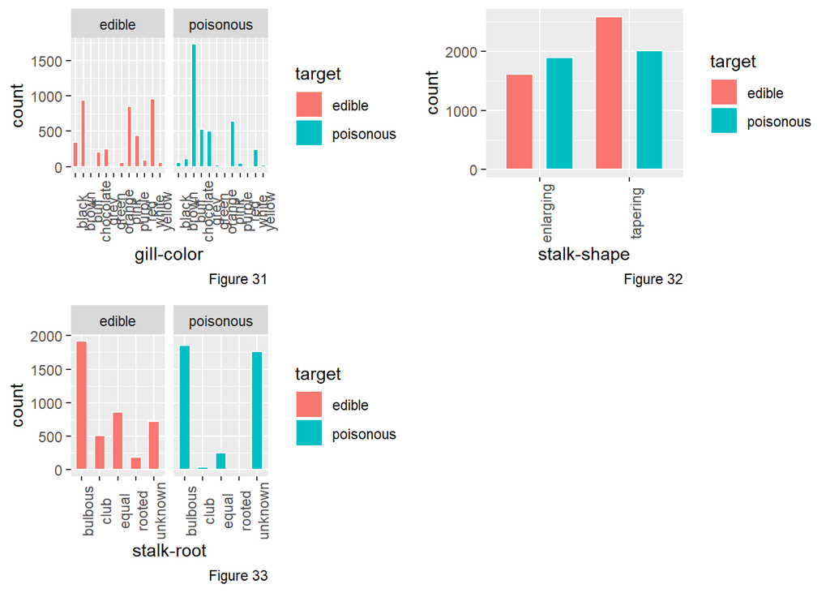

```r
sr.t <- ggplot(data3, aes(x=`stalk-root`)) +
  geom_bar(aes(fill= target), color="white", position = position_dodge(0.9), width = 0.6) + labs(caption="Figure 33") +
  facet_wrap(~target) +
  theme(axis.text.x = element_text(angle = 90))
grid.arrange((gc.t), (ss.t), (sr.t), ncol=2)
```

From Fig 31, The buff and green color are always poisonous whereas orange and red are always edible . Brown, black, pink, purple, white are more likely to be edible whereas chocolate and grey are more likely to be poisonous.

From Fig 32, The plot suggests that enlarging shape is more likely to be poisonous whereas tapering shape is more likely to be edible.

From Fig 33, The stalk root type ‘rooted’ is always edible.

# d.Stalk-surface-above-ring, stalk-color-above-ring, veil-color, ring-number

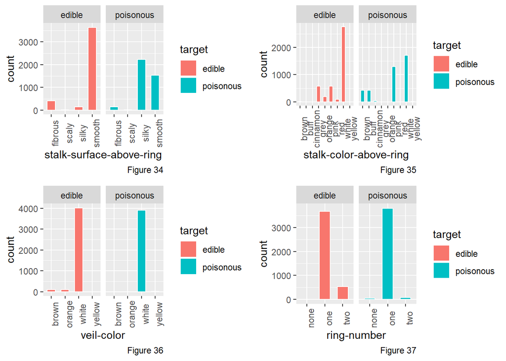

```r
ssar.t <- ggplot(data3, aes(x=`stalk-surface-above-ring`)) +
  geom_bar(aes(fill= target), color="white", position = position_dodge(0.9), width = 0.6) + labs(caption="Figure 34") +
  facet_wrap(~target) +
  theme(axis.text.x = element_text(angle = 90))
scar.t <- ggplot(data3, aes(x=`stalk-color-above-ring`)) +
  geom_bar(aes(fill= target), color="white", position = position_dodge(0.9), width = 0.6) + labs(caption="Figure 35") +
  facet_wrap(~target) +
  theme(axis.text.x = element_text(angle = 90))
vc.t <- ggplot(data3, aes(x=`veil-color`)) +
  geom_bar(aes(fill= target), color="white", position = position_dodge(0.9), width = 0.6) + labs(caption="Figure 36") +
  facet_wrap(~target) +
  theme(axis.text.x = element_text(angle = 90))
rn.t <- ggplot(data3, aes(x=`ring-number`)) +
  geom_bar(aes(fill= target), color="white", position = position_dodge(0.9), width = 0.6) + labs(caption="Figure 37") +
  facet_wrap(~target) +
  theme(axis.text.x = element_text(angle = 90))
grid.arrange((ssar.t), (scar.t), (vc.t), (rn.t), ncol=2)
```

From Fig 34, The smooth type is more likely to be edible, whereas silky type is more likely to be poisonous.

From Fig 35, The grey and orange color is never poisonous. Whereas, the buff color is always poisonous.

From Fig 36, Both brown and orange colored mushrooms are always edible.

From Fig 37, with even distribution of a sinlge ring mushrooms, the two ring mushrooms are more likely edible.

# e.Ring-type, spore-print-color, population, habitat

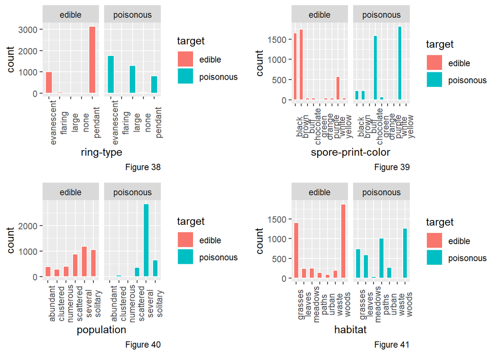

```r
rt.t <- ggplot(data3, aes(x=`ring-type`)) +
  geom_bar(aes(fill= target), color="white", position = position_dodge(0.9), width = 0.6) + labs(caption="Figure 38") +
  facet_wrap(~target) +
  theme(axis.text.x = element_text(angle = 90))
spc.t <- ggplot(data3, aes(x=`spore-print-color`)) +
  geom_bar(aes(fill= target), color="white", position = position_dodge(0.9), width = 0.6) + labs(caption="Figure 39") +
  facet_wrap(~target) +
  theme(axis.text.x = element_text(angle = 90))
p.t <- ggplot(data3, aes(x=population)) +
  geom_bar(aes(fill= target), color="white", position = position_dodge(0.9), width = 0.6) + labs(caption="Figure 40") +
  facet_wrap(~target) +
  theme(axis.text.x = element_text(angle = 90))
h.t <- ggplot(data3, aes(x=habitat)) +
  geom_bar(aes(fill= target), color="white", position = position_dodge(0.9), width = 0.6) + labs(caption="Figure 41") +
  facet_wrap(~target) +
  theme(axis.text.x = element_text(angle = 90))
grid.arrange((rt.t), (spc.t), (p.t), (h.t), ncol=2)
```

From Fig 38, the pendant type is more likely to be edible and large type is always almost poisonous.

From Fig 39, Black or brown colored mushrooms are most likely edible.

From Fig 40, Several type is more likely to be poisonous.

From Fig 41, Grasses and woods are more likely to be edible.

```r
## Converting the data into csv file for phase 2 in python
str(data3)
```

```
## Classes 'tbl_df', 'tbl' and 'data.frame':    8124 obs. of  20 variables:
##  $ cap-shape               : Factor w/ 6 levels "bell","conical",..: 3 3 1 3 3 3 1 1 3 1 ...
##  $ cap-surface             : Factor w/ 4 levels "fibrous","grooves",..: 4 4 4 3 4 3 4 3 3 4 ...
##  $ cap-color               : Factor w/ 10 levels "brown","buff",..: 1 10 9 9 4 10 9 9 9 10 ...
##  $ bruises                 : Factor w/ 2 levels "yes","no": 1 1 1 1 2 1 1 1 1 1 ...
##  $ odor                    : Factor w/ 9 levels "almond","anise",..: 8 1 2 8 7 1 1 2 8 1 ...
##  $ gill-attachment         : Factor w/ 4 levels "attached","descending",..: 3 3 3 3 3 3 3 3 3 3 ...
##  $ gill-spacing            : Factor w/ 3 levels "close","crowded",..: 1 1 1 1 2 1 1 1 1 1 ...
##  $ gill-size               : Factor w/ 2 levels "broad","narrow": 2 1 1 2 1 1 1 1 2 1 ...
##  $ gill-color              : Factor w/ 12 levels "black","brown",..: 1 1 2 2 1 2 5 2 8 5 ...
##  $ stalk-shape             : Factor w/ 2 levels "enlarging","tapering": 1 1 1 1 2 1 1 1 1 1 ...
##  $ stalk-root              : Factor w/ 7 levels "bulbous","club",..: 4 2 2 4 4 2 2 2 4 2 ...
##  $ stalk-surface-above-ring: Factor w/ 4 levels "fibrous","scaly",..: 4 4 4 4 4 4 4 4 4 4 ...
##  $ stalk-color-above-ring  : Factor w/ 9 levels "brown","buff",..: 8 8 8 8 8 8 8 8 8 8 ...
##  $ veil-color              : Factor w/ 4 levels "brown","orange",..: 3 3 3 3 3 3 3 3 3 3 ...
##  $ ring-number             : Factor w/ 3 levels "none","one","two": 2 2 2 2 2 2 2 2 2 2 ...
##  $ ring-type               : Factor w/ 8 levels "cowebby","evanescent",..: 6 6 6 6 2 6 6 6 6 6 ...
##  $ spore-print-color       : Factor w/ 9 levels "black","brown",..: 1 2 2 1 2 1 1 2 1 1 ...
##  $ population              : Factor w/ 6 levels "abundant","clustered",..: 4 3 3 4 1 3 3 4 5 4 ...
##  $ habitat                 : Factor w/ 7 levels "grasses","leaves",..: 5 1 3 5 1 1 3 3 1 3 ...
##  $ target                  : Factor w/ 2 levels "edible","poisonous": 2 1 1 2 1 1 1 1 2 1 ...
```

```r
write.csv(data3, file = "mushroom_phase1_csv")
```

## Summary

In Phase 1, We pre-processed and re-arranged the data for the purpose of ease of understanding. We renamed the target feature as ‘target’. We removed ‘veil-type’, ‘stalk-surface-below-ring’ and ‘stalk-color-below-ring’ variables on the basis of insignificance and redundancy. In Data Exploration step we understood the distribution of different samples among different categories of each variable. From multivariate data exploration, we deduced relationship between target feature and other features of dataset. These categorical features could be the potentially useful features in predicting whether the mushroom is edible or poisonous.